# Devoir maison obligatoire : Modèle linéaire Généralisé et Choix de modèles

Sylvain BENOIT

31 août 2019

# Présentation des données : Prédire les jours de pluie à Bâle

Comme renseigné dans l’énoncé, le fichier `meteo.train.csv` contient des données sur les conditions météorologiques à Bâle (Suisse). Chaque ligne correspond à un jour entre 2010 et 2018. Bien que ces observatons soient reportées dans l’ordre chronologique, ces jours ne sont pas systématiquement consécutifs, certains d’entre eux sont dans la base test correspondant au fichier `meteo.test.csv`. Nous décidons donc de ne pas utiliser un modèle utilisant des variables retardées. En d’autres termes, seules les observations du jour même sont utilisées pour prévoir s’il va pleuvoir demain (variable `pluie.demain`). Bien que dommageable car il nous est dès lors impossible de prendre en compte dans le temps l’évolution des épisodes météorologiques, cette hypothèse de travail nous semble moins contraignante pour réaliser des prévisions immédiates (ayant une échéance de quelques heures). Les colonnes (variables) correspondent aux valeurs moyennes, minimales et maximales sur la journée de :

- Température (en °C): `Temperature.Mean`, `Temperature.Max`, `Temperature.Min`;
- Humidité relative (en pourcentage): `RelHumidity.Mean`, `RelHumidity.Max`, `RelHumidity.Min`;
- Pression (en hPa): `Pressure.Mean`, `Pressure.Max`, `Pressure.Min`;
- Nébulosité (en pourcentage): `TotalCloudCover.Mean`, `TotalCloudCover.Max`, `TotalCloudCover.Min`;
- Nébulosité forte, moyenne et faible (en pourcentage): `HighCloudCover.Mean`, `HighCloudCover.Max`, `HighCloudCover.Min`, `MediumCloudCover.Mean`, `MediumCloudCover.Max`, `MediumCloudCover.Min`, `LowCloudCover.Mean`, `LowCloudCover.Max`, `LowCloudCover.Min`;
- Vitesse (en km/h) du vent à 10 m d’altitude, 80 m d’altitude, et à l’altitude où la pression vaut 900 hPa: `WindSpeed.Mean.10m`, `WindSpeed.Mean.80m`, `WindSpeed.Mean.900hPa`, `WindSpeed.Max.10m`, `WindSpeed.Max.80m`, `WindSpeed.Max.900hPa`, `WindSpeed.Min.10m`, `WindSpeed.Min.80m`, `WindSpeed.Min.900hPa`;
- Direction (en degrés) du vent à 10 m d’altitude, 80 m d’altitude, et à l’altitude où la pression vaut 900 hPa: `WindDirection.Mean.10m`, `WindDirection.Mean.80m`, `WindDirection.Mean.900hPa`;
- Rafales de vent à 10 m: `WindGust.Mean`, `WindGust.Max`, `WindGust.Min`;

ainsi qu’aux valeurs totales sur la journée de :

- Précipitations (en mm): `TotalPrecipitation.Sum`;
- Neige (en cm): `Snowfall.Sum`;
- Minutes d’ensoleillement: `SunshineDuration.Sum`;
- Rayonnement solaire (W/m2): `ShortwaveRadiation.Sum`;

Pour plus de clarté les noms des 40 variables explicatives ont été recodées.

```r
# Refresh the environment of R
rm(list = ls(all = TRUE))

# Set the folder path to download and upload your dataset
setwd("F:/Dropbox/Dauphine-SDFi/DauphineDigital/DM_mlg")

# Import your dataset
meteo_train = read.csv("meteo.train.csv")

# To extract columns' names
dput(names(meteo_train))
```

```
## c("X", "Year", "Month", "Day", "Hour", "Minute", "Temperature.daily.mean..2.m.above.gnd.",
## "Relative.Humidity.daily.mean..2.m.above.gnd.", "Mean.Sea.Level.Pressure.daily.mean..MSL.",
## "Total.Precipitation.daily.sum..sfc.", "Snowfall.amount.raw.daily.sum..sfc.",
## "Total.Cloud.Cover.daily.mean..sfc.", "High.Cloud.Cover.daily.mean..high.cld.lay.",
## "Medium.Cloud.Cover.daily.mean..mid.cld.lay.", "Low.Cloud.Cover.daily.mean..low.cld.lay.",
## "Sunshine.Duration.daily.sum..sfc.", "Shortwave.Radiation.daily.sum..sfc.",
## "Wind.Speed.daily.mean..10.m.above.gnd.", "Wind.Direction.daily.mean..10.m.above.gnd.",
## "Wind.Speed.daily.mean..80.m.above.gnd.", "Wind.Direction.daily.mean..80.m.above.gnd.",
## "Wind.Speed.daily.mean..900.mb.", "Wind.Direction.daily.mean..900.mb.",
## "Wind.Gust.daily.mean..sfc.", "Temperature.daily.max..2.m.above.gnd.",
## "Temperature.daily.min..2.m.above.gnd.", "Relative.Humidity.daily.max..2.m.above.gnd.",
## "Relative.Humidity.daily.min..2.m.above.gnd.", "Mean.Sea.Level.Pressure.daily.max..MSL.",
## "Mean.Sea.Level.Pressure.daily.min..MSL.", "Total.Cloud.Cover.daily.max..sfc.",
## "Total.Cloud.Cover.daily.min..sfc.", "High.Cloud.Cover.daily.max..high.cld.lay.",
## "High.Cloud.Cover.daily.min..high.cld.lay.", "Medium.Cloud.Cover.daily.max..mid.cld.lay.",
## "Medium.Cloud.Cover.daily.min..mid.cld.lay.", "Low.Cloud.Cover.daily.max..low.cld.lay.",
## "Low.Cloud.Cover.daily.min..low.cld.lay.", "Wind.Speed.daily.max..10.m.above.gnd.",
## "Wind.Speed.daily.min..10.m.above.gnd.", "Wind.Speed.daily.max..80.m.above.gnd.",
## "Wind.Speed.daily.min..80.m.above.gnd.", "Wind.Speed.daily.max..900.mb.",
## "Wind.Speed.daily.min..900.mb.", "Wind.Gust.daily.max..sfc.",
## "Wind.Gust.daily.min..sfc.", "pluie.demain")
```

```r
# Copy/Paste the previous output from your console and rename this list accordingly
names(meteo_train) <- c("X", "Year", "Month", "Day", "Hour", "Minute", "Temperature.Mean",
                            "RelHumidity.Mean", "Pressure.Mean", "TotalPrecipitation.Sum",
                            "Snowfall.Sum", "TotalCloudCover.Mean",
                            "HighCloudCover.Mean", "MediumCloudCover.Mean", "LowCloudCover.Mean",
                            "SunshineDuration.Sum", "ShortwaveRadiation.Sum",
                            "WindSpeed.Mean.10m", "WindDirection.Mean.10m",
                            "WindSpeed.Mean.80m", "WindDirection.Mean.80m",
                            "WindSpeed.Mean.900hPa", "WindDirection.Mean.900hPa",
                            "WindGust.Mean",
                            "Temperature.Max", "Temperature.Min",
                            "RelHumidity.Max", "RelHumidity.Min", "Pressure.Max", "Pressure.Min",
                            "TotalCloudCover.Max", "TotalCloudCover.Min",
                            "HighCloudCover.Max", "HighCloudCover.Min",
                            "MediumCloudCover.Max", "MediumCloudCover.Min",
                            "LowCloudCover.Max", "LowCloudCover.Min",
                            "WindSpeed.Max.10m", "WindSpeed.Min.10m",
                            "WindSpeed.Max.80m", "WindSpeed.Min.80m",
                            "WindSpeed.Max.900hPa", "WindSpeed.Min.900hPa",
                            "WindGust.Max", "WindGust.Min",
                            "pluie.demain"
)
```

# Sélection des variables explicatives

Cette section propose une analyse descriptive des 40 variables explicatives. Cette analyse est nécessaire puisque de nombreuses variables observent vraisemblablement les mêmes caractéristiques météorologiques[^1]. De nouvelles variables explicatives sont également proposées sur la base de nos recherches sur le sujet.

## Analyse des corrélations: variables redondantes

Le jeu de données contenant les valeurs moyennes, maximales et minimales pour un certain nombre devariables, nous décidons d’analyser les corrélations entre ces dernières afin d’éliminer de potentiel variables redondantes.

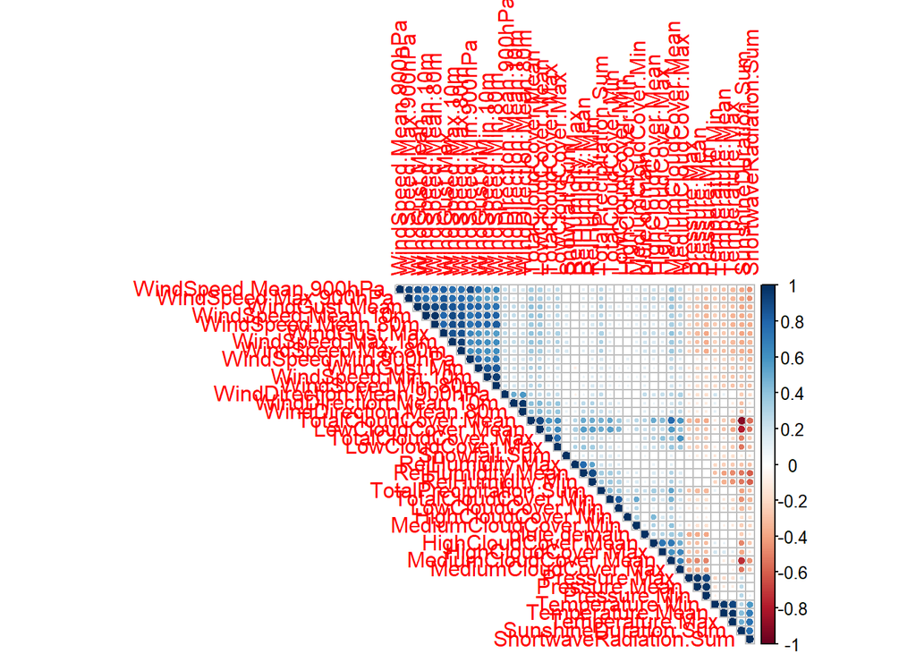

```r
# Correlations among our 40 numeric explanatory variables

# Selecting only the subset of our 40 explanatory variables
exp.var = subset(meteo_train, select = -c(X, Year, Month, Day, Hour, Minute))

# Correlation computation with their pvalues
library("Hmisc")
corr.exp.var <- rcorr(as.matrix(exp.var))
# The correlation coefficients are in corr.exp.var$r whereas pvalues are in corr.exp.var$p

# Draw a correlogram
library(corrplot)
# Insignificant correlations are leaved blank
corrplot(corr.exp.var$r, type="upper", order="hclust",
         p.mat = corr.exp.var$P, sig.level = 0.01, insig = "blank")
```

L’analyse du corrélogramme, nous permet de poursuivre l’étude sur des sous-échantillons de variables corrélées positivement entre pour plus de lisibilité. Afin de sélectionner au mieux nos variables, la corrélation avec la variable dépendante est également calculée.

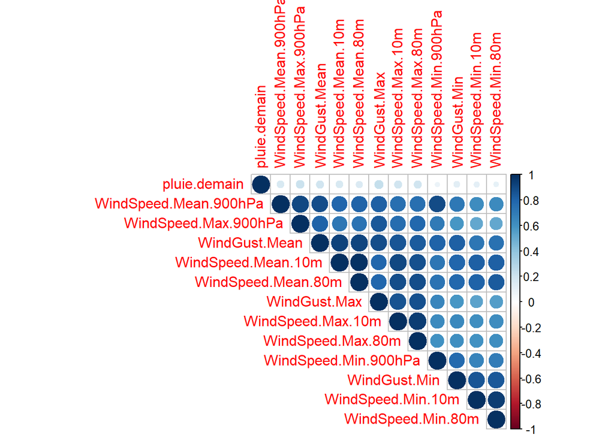

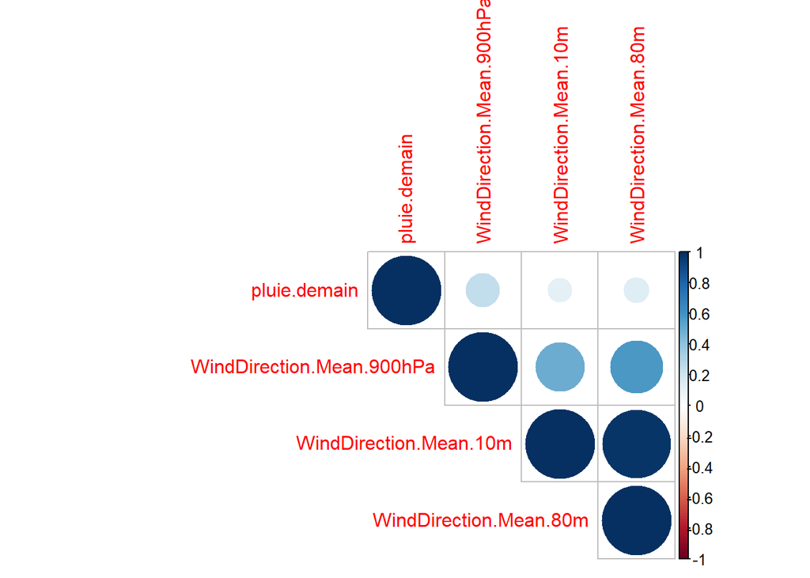

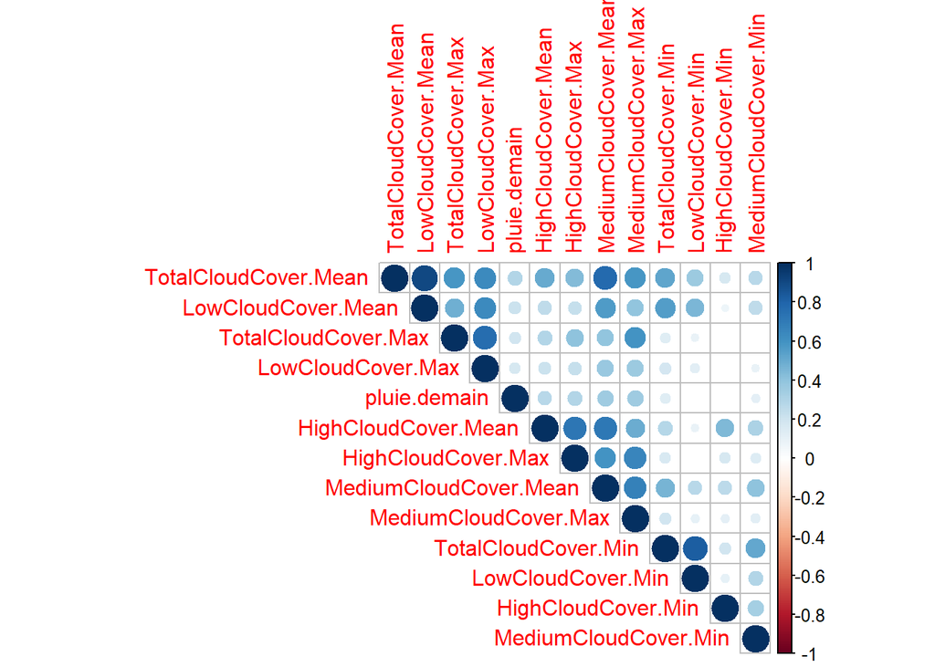

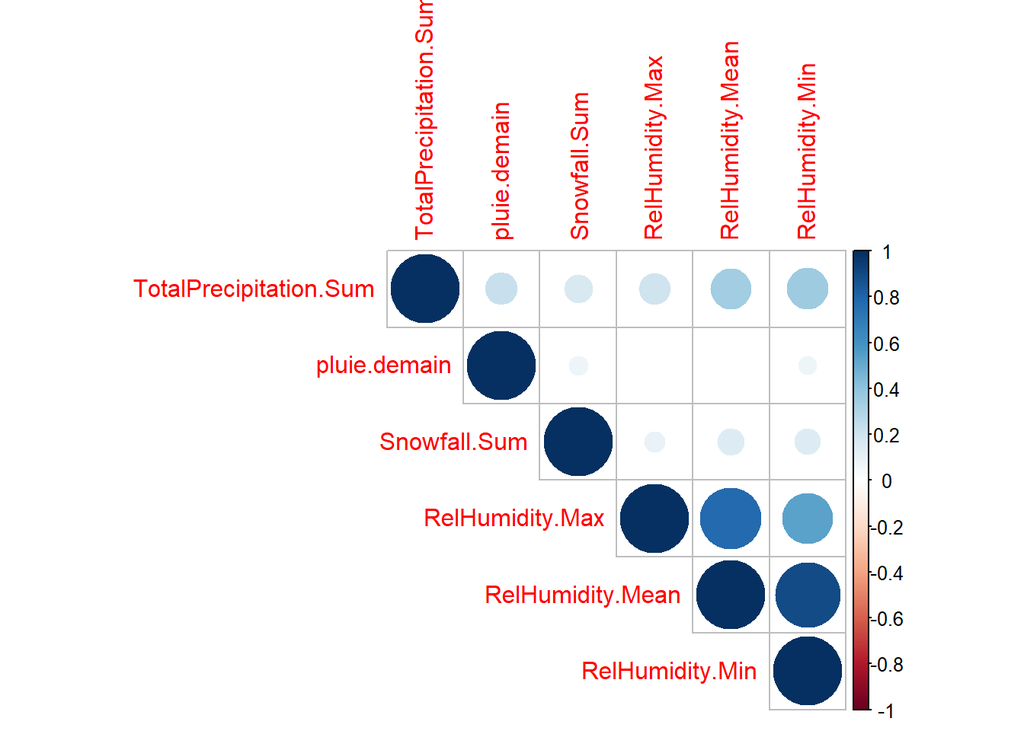

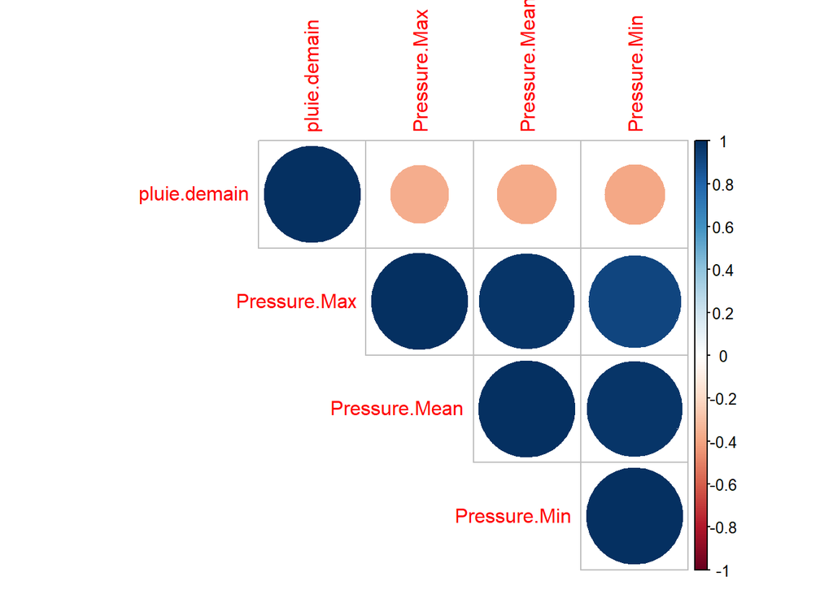

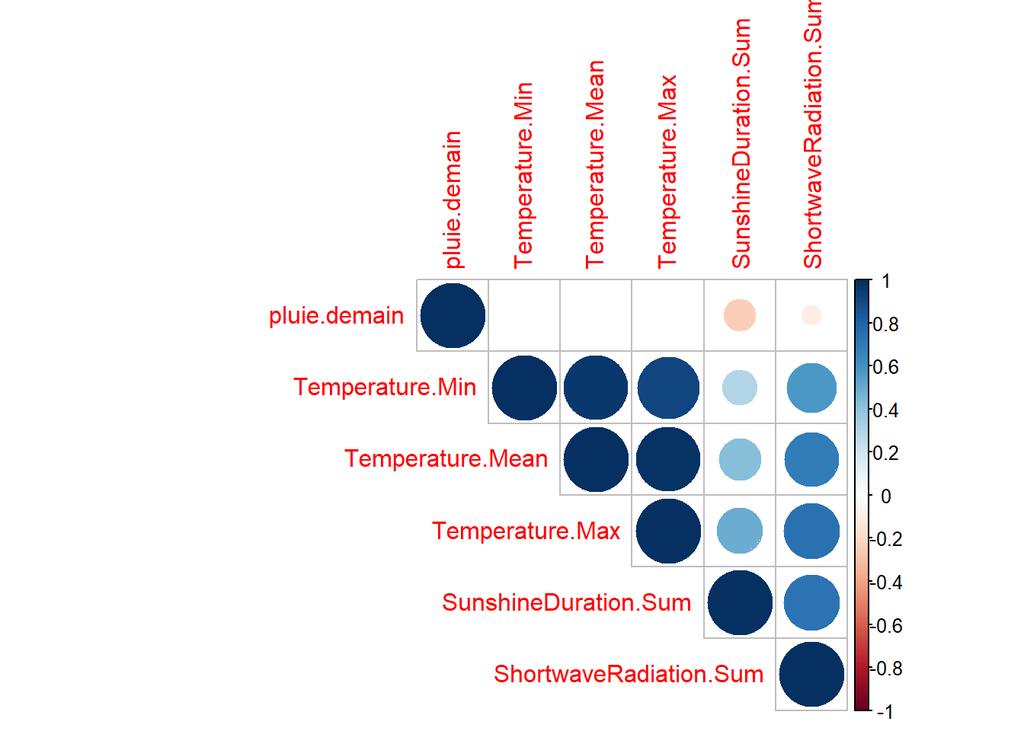

D’après le premier graphique, nous décidons de conserver les variables `WindSpeed.Mean.900hPa` et `WindGust.Max` car pour une altitude (pression atmosphérique) identique, les variables `.Mean`, `.Max` et `Min` ont de très fortes corrélations (supérieur à 80%). Les variables `.Max` sot ici les plus corrélées avec la variables dépendante, nous décidons donc de sélectionner celle avec la plus forte corrélation avec la variables dépendante (`WindGust.Max`). La variable `WindSpeed.Mean.900hPa` est préférée à la variable `WindSpeed.Max.900hPa` (plus corrélée avec la dépendante) afin de limiter la corrélation avec la pécédente variables sélectionnée.

D’après le deuxième graphique, c’est la variable `WindDirection.Mean.900hPa` qui est retenue car la plus corrélée avec la variable `pluie.demain`. La direction du vent à 10 mètres (`WindDirection.Mean.10m`) pourrait également être conservée car peu corrélée avec notre variables sélectionnée.

D’après le troisième graphique, ce sont les variables `TotalCloudCover.Mean`, `HighCloudCover.Max`, `MediumCloudCover.Max` et `LowCloudCover.Max`. Les variables `.Min` n’étant pas corrélée avec la variable dépendante, nous n’en conservons pas. En effet, en l’absence de nuage, il est peu probable qu’il pleuve. Les variables `.Max`sont privilégiées pour les trois niveaux de couverture nuageuses afin de capter la présence d’un ciel de traîne. Ne sachant pas exactement à quelle altitude se juge la couverture nuageuse basse, moyenne et haute, nous avons décidé de prendre une variable de chacune de ses catégories. La couvertuire nuageuse totale, permet d’avoir une observation moyenne sur la journée. On s’attend à ce que plus la couverture nuageuse soit élevée, plus la probabilité de pluie le lendemain est importante.

D’après le quatrième graphique, la variable dépendante `pluie.demain` est corrélée positivement et significativement avec les trois variables suivantes : `TotalPrecipitation.Sum`, `Snowfall.Sum` et `RelHumidity.Min`; nous décidons donc des sélectionner.

D’après le cinquième graphique, la pression atmosphérique est corrélée négativement et significativement avec la varibale dépendante. Les phénomènes pluvieux se produisent lorsque la pression atmosphérique est basse. Afin de capter si une basse pression a été observée durqnt la journée, nous sélectionnons la variable `Pressure.Min`, ce choix est également guidé par le fait que sa corrélation avec la variable dépendante est la plus forte parmi les trois (-38,41% contre -37,82% avec `Pressure.Mean` et -36.29% avec `Pressure.Max`).

Nous avons donc sélectionné les 13 (14) variables explicatives suivantes pour poursuivre l’analyse : `WindSpeed.Mean.900hPa`, `WindGust.Max`, `WindDirection.Mean.900hPa`, `TotalCloudCover.Mean`, `HighCloudCover.Max`, `MediumCloudCover.Max`, `LowCloudCover.Max`, `TotalPrecipitation.Sum`, `Snowfall.Sum`, `RelHumidity.Min`, `Pressure.Min`, `SunshineDuration.Sum`, `ShortwaveRadiation.Sum` et potentiellement `WindDirection.Mean.10m`.

# Création de nouvelles variables explicatives

Les observations étant datées, nous souhaitons prendre en compte le mois et la saison dans notre analyse. Nous ajoutons donc ces 2 variables à notre base de données, `Month.fac` possède 12 classes tandis que `Season.fac` en a 4.

```r
# Month as a factor
meteo_train$Month.fac <- factor(meteo_train$Month)

# Create Season as variable
library(dplyr)
meteo_train <-
  mutate(meteo_train,
    Season = case_when(
      Month.fac %in% 10:12 ~ "Fall",
      Month.fac %in%  1:3  ~ "Winter",
      Month.fac %in%  4:6  ~ "Spring",
      TRUE ~ "Summer"))
# Season as a factor
meteo_train$Season.fac <- factor(meteo_train$Season)
```

La direction du vent étant exprimé en degré, nous décidons de recoder la variable `WindDirection.Mean.900hPa` en 16 classes afin de construire une rose des vents. D’après la méthode Moreux, le temps en Europe dépend de 5 sortes de masses d’air : arctique, polaire continentale, tropicale continentale, tropicale maritime et polaire maritime. Ce sont ces 5 sortes de masses d’air que nous souhaitons associer à la direction du vent. Les vents maritimes qu’ils soient tropicaux ou polaires sont plutôt associé au mauvais temps. Au final, notre nouvelle variable `WindDirectionMoreux.Mean.900hPa` est constitué de 5 classes. D’après nos résultats ci-dessous, ce sont bien les vents maritimes qui engendrent le plus de précipitations et en particulier l’air tropical maritime.

```r
# Sliced variable
meteo_train$WindDirectionCardi16.Mean.900hPa <- cut(meteo_train$WindDirection.Mean.900hPa, seq(0, 360, length.out=17),
                                                 labels = c( "N", "NNE", "NE", "ENE", "E", "ESE", "SE", "SSE", "S",
                                                            "SSO", "SO", "OSO", "O", "ONO", "NO", "NNO"))
# Descriptive statistics, only the sum of event per class
summary(meteo_train$WindDirectionCardi16.Mean.900hPa)
```

```
##   N NNE  NE ENE   E ESE  SE SSE   S SSO  SO OSO   O ONO  NO NNO
##   0   9  32  99  83  48  59  67  55  97 158 287 181  55  11   3
```

```r
# Table with the dependent variable
table(meteo_train$WindDirectionCardi16.Mean.900hPa,meteo_train$pluie.demain)
```

```
##
##       FALSE TRUE
##   N       0    0
##   NNE     8    1
##   NE     22   10
##   ENE    79   20
##   E      64   19
##   ESE    29   19
##   SE     36   23
##   SSE    36   31
##   S      23   32
##   SSO    40   57
##   SO     52  106
##   OSO   112  175
##   O      90   91
##   ONO    28   27
##   NO      6    5
##   NNO     0    3
```

```r
# Air mass names
meteo_train$WindDirectionMoreux.Mean.900hPa[meteo_train$WindDirectionCardi16.Mean.900hPa == "NO" |  meteo_train$WindDirectionCardi16.Mean.900hPa == "NNO"| meteo_train$WindDirectionCardi16.Mean.900hPa == "N" | meteo_train$WindDirectionCardi16.Mean.900hPa == "NNE"] <- " Arctique"
meteo_train$WindDirectionMoreux.Mean.900hPa[meteo_train$WindDirectionCardi16.Mean.900hPa == "NE" | meteo_train$WindDirectionCardi16.Mean.900hPa == "ENE" | meteo_train$WindDirectionCardi16.Mean.900hPa == "E"] <- " Polaire continental"
meteo_train$WindDirectionMoreux.Mean.900hPa[meteo_train$WindDirectionCardi16.Mean.900hPa == "ESE" | meteo_train$WindDirectionCardi16.Mean.900hPa == "SE" | meteo_train$WindDirectionCardi16.Mean.900hPa == "SSE"] <- " Tropical continental"
meteo_train$WindDirectionMoreux.Mean.900hPa[meteo_train$WindDirectionCardi16.Mean.900hPa == "S" | meteo_train$WindDirectionCardi16.Mean.900hPa == "SSO" | meteo_train$WindDirectionCardi16.Mean.900hPa == "SO" | meteo_train$WindDirectionCardi16.Mean.900hPa == "OSO"] <- " Tropical maritime"
meteo_train$WindDirectionMoreux.Mean.900hPa[meteo_train$WindDirectionCardi16.Mean.900hPa == "O" | meteo_train$WindDirectionCardi16.Mean.900hPa == "ONO"] <- " Polaire maritime"
# WindDirectionMoreux.Mean.900hPa as a factor
meteo_train$WindDirectionMoreux.Mean.900hPa.fac <- factor(meteo_train$WindDirectionMoreux.Mean.900hPa)
# Descriptive statistics, only the sum of event per class
summary(meteo_train$WindDirectionMoreux.Mean.900hPa.fac)
```

```
##              Arctique   Polaire continental      Polaire maritime
##                    23                   214                   236
##  Tropical continental     Tropical maritime
##                   174                   597
```

```r
# Table with the dependent variable
table(meteo_train$WindDirectionMoreux.Mean.900hPa.fac,meteo_train$pluie.demain)
```

```
##
##                         FALSE TRUE
##    Arctique                14    9
##    Polaire continental    165   49
##    Polaire maritime       118  118
##    Tropical continental   101   73
##    Tropical maritime      227  370
```

Désormais, nous souhaitons également définir des classes pour la force du vent et la pression atmosphérique. Pour cela, nous repartons de la variable `WindSpeed.Mean.900hPa` pour la vitesse du vent et de `Pressure.Mean` pour la pression atmosphérique. Météo france propose une [qualification du vent](http://www.meteofrance.fr/publications/glossaire/153463-qualification-du-vent) en 6 classes en fonction de sa vitesse. Pour le pression atmosphérique, au dessus de 1020 hPa, nous sommes en présence d’une celluel anticyclonique, en dessous, nous décomposons les zones dépressionnaire en trois. Lorsque la pression atmosphérique est en dessous de 1020 hPa, il y a plus de jours de pluie le lendemain.

```r
# Sliced WindSpeed variable
meteo_train$WindSpeedForce.Mean.900hPa <- cut(meteo_train$WindSpeed.Mean.900hPa, c(min(meteo_train$WindSpeed.Mean.900hPa),2,12,30,50,75,max(meteo_train$WindSpeed.Mean.900hPa)), labels= c("Vent calme", "Vent faible", "Vent modéré", "Vent assez fort", "Vent fort", "Vent très fort"))
# Table with the dependent variable
table(meteo_train$WindSpeedForce.Mean.900hPa,meteo_train$pluie.demain)
```

```
##
##                   FALSE TRUE
##   Vent calme          1    0
##   Vent faible       140   95
##   Vent modéré       347  319
##   Vent assez fort   104  127
##   Vent fort          29   63
##   Vent très fort      4   15
```

```r
# Sliced WindSpeed variable
meteo_train$PressureName.Mean <- cut(meteo_train$Pressure.Mean, c(min(meteo_train$Pressure.Mean), 1006, 1013, 1020, max(meteo_train$Pressure.Mean)), include.lowest = TRUE, labels = c("inf1006", "1006-1013", "1013-1020", "sup1020"))
# Table with the dependent variable
table(meteo_train$PressureName.Mean,meteo_train$pluie.demain)
```

```
##
##             FALSE TRUE
##   inf1006      17   83
##   1006-1013    69  165
##   1013-1020   251  279
##   sup1020     288   92
```

Pour récapituler, les variables que nous venons de créer et que nous allons utiliser dans la suite de l’analyse se nomment : `Month.fac`, `Season.fac`, `WindDirectionMoreux.Mean.900hPa.fac`, `WindSpeedForce.Mean.900hPa` et `PressureName.Mean`. Ces variables étant des facteurs, cela augmente considérablement le nombre potentiel de coefficients à estimer.

## Régressions logistiques

Nous utilisons dans un premier temps la fonction glmulti() pour sélectionner le modèle optimale car nous avons des variables avec plus de deux classes et il se peut que notre modèle soit non linéaire.[^2] Cette fonction a pour objectif de trouver le modèle minimisant un critère d’information. La méthode exhaustive de cette fonction étant trop longue (car trop de variables explicatives), nous utilisons l’algorithme génétique pour trouver le meilleur modèle.

# Choix du modèle : sélection des variables

Nous décidons de minimiser le critère BIC car le terme de pénalité est plus élevé que dans le critère AIC, ceci nous permet d’obtenir des modèles plus parcimonieux. Nous proposons à la fonction 5 ensemble de variables différents pour mener l’analyse, pour chacun des modèles, nous récupérons uniquement les 3 meilleurs modèles :

Afin de résumer les résultats obtenus (nous avons 15 modèles concurrents), nous décidons de nous concentrer sur 4 critères :

- La courbe ROC (receiver operating characteristic) qui est un graphique représentant les performances d’un modèle de classification pour tous les seuils de classification. Cette courbe trace le taux de vrais positifs en fonction du taux de faux positifs. Nous nous intéressons plus particulièrement à l’air sous cette courbe (Area Under the Curve), l’objectif étant de maximiser cette quantité.
- Le taux de bonnes prédictions, l’objectif étant également de le maximiser
- L’erreur absolue moyenne (MAE), que l’on souhaite minimiser.
- La racine carré de l’erreur quadratique moyenne (RMSE) que l’on minimise également.

Quatre tableaux récapitulatifs résument donc les résultats. Il faut remarquer ici que les coefficients estimés pour le meilleur modèle provenant des Modèles A, B, C et E sont bien significativement différent de 0. De plus, les variables à facteur que nous avons créées n’apportent rien à notre analyse, soit elles ne ressortent pas dans les meilleurs modèles ou si elles ressortent, les coefficients associés à ces variables sont rarement significativement différents de 0. Enfin, les modèles estimés lorsque les interactions sont prises en compte varient à chaque fois que le code est exécuté, ceci vient du fait que l’on utilise l’algorithme génétique.

Les coefficients estimés ne peuvent pas être interpréter directement comme dans le cas des modèles de régression linéaire simple. Dans une régression logistique seul le signe du coefficient estimé s’interprète directement, le signe moins signifie que la probabilité d’observer l’évènement que l’on cherche à prédire (s’il pleut demain à Bâle dans notre étude) diminue lorsque la variable associé croît, tandis que le signe plus nous indique que cette probabilité augmente lorsque la valeur de la variable explicative croît.

```r
library(glmulti)
# Model A
glmulti.logit.out.A <-
  glmulti(pluie.demain ~ WindSpeed.Mean.900hPa + WindGust.Max + WindDirection.Mean.900hPa + TotalCloudCover.Mean + HighCloudCover.Max + MediumCloudCover.Max + LowCloudCover.Max + TotalPrecipitation.Sum + Snowfall.Sum + RelHumidity.Min + Pressure.Min + SunshineDuration.Sum + ShortwaveRadiation.Sum + WindDirection.Mean.10m, data = meteo_train,
          level = 1,               # 1: No interaction considered; 2: pairwise interaction between covariates
          method = "g",            # h: Exhaustive approach; 2: genetic algorithm
          crit = "bic",            # BIC as criteria
          confsetsize = 3,         # Keep 3 best models
          plotty = F, report = F,  # No plot or interim reports
          fitfunction = "glm",     # glm function
          family = binomial)       # binomial family for logistic regression
```

[output not shown]

```r
# Show the 3 best models (Use @ instead of $ for an S4 object)
glmulti.logit.out.A@formulas
```

```
## [[1]]
## pluie.demain ~ 1 + WindDirection.Mean.900hPa + MediumCloudCover.Max +
##     Pressure.Min
## <environment: 0x000000001732b570>
##
## [[2]]
## pluie.demain ~ 1 + WindDirection.Mean.900hPa + HighCloudCover.Max +
##     MediumCloudCover.Max + Pressure.Min
## <environment: 0x000000001732b570>
##
## [[3]]
## pluie.demain ~ 1 + WindDirection.Mean.900hPa + TotalCloudCover.Mean +
##     MediumCloudCover.Max + Pressure.Min
## <environment: 0x000000001732b570>
```

```r
# Show results for the best model from Model A
summary(glmulti.logit.out.A@objects[[1]])
```

```
##
## Call:
## fitfunc(formula = as.formula(x), family = ..1, data = data)
##
## Deviance Residuals:
##     Min       1Q   Median       3Q      Max
## -2.0983  -0.9442  -0.3174   0.9531   2.2385
##
## Coefficients:
##                             Estimate Std. Error z value Pr(>|z|)
## (Intercept)               84.6378879  9.5398764   8.872  < 2e-16 ***
## WindDirection.Mean.900hPa  0.0043137  0.0009229   4.674 2.96e-06 ***
## MediumCloudCover.Max       0.0116679  0.0017990   6.486 8.83e-11 ***
## Pressure.Min              -0.0852250  0.0093676  -9.098  < 2e-16 ***
## ---
## Signif. codes:  0 '***' 0.001 '**' 0.01 '*' 0.05 '.' 0.1 ' ' 1
##
## (Dispersion parameter for binomial family taken to be 1)
##
##     Null deviance: 1724.5  on 1243  degrees of freedom
## Residual deviance: 1432.4  on 1240  degrees of freedom
## AIC: 1440.4
##
## Number of Fisher Scoring iterations: 4
```

```r
summary(glmulti.logit.out.A@objects[[2]])
```

```
##
## Call:
## fitfunc(formula = as.formula(x), family = ..1, data = data)
##
## Deviance Residuals:
##     Min       1Q   Median       3Q      Max
## -1.9682  -0.9525  -0.3156   0.9443   2.2511
##
## Coefficients:
##                             Estimate Std. Error z value Pr(>|z|)
## (Intercept)               83.7532050  9.5449115   8.775  < 2e-16 ***
## WindDirection.Mean.900hPa  0.0042467  0.0009267   4.583 4.59e-06 ***
## HighCloudCover.Max         0.0045711  0.0019434   2.352   0.0187 *
## MediumCloudCover.Max       0.0087037  0.0021944   3.966 7.30e-05 ***
## Pressure.Min              -0.0844067  0.0093720  -9.006  < 2e-16 ***
## ---
## Signif. codes:  0 '***' 0.001 '**' 0.01 '*' 0.05 '.' 0.1 ' ' 1
##
## (Dispersion parameter for binomial family taken to be 1)
##
##     Null deviance: 1724.5  on 1243  degrees of freedom
## Residual deviance: 1426.9  on 1239  degrees of freedom
## AIC: 1436.9
##
## Number of Fisher Scoring iterations: 4
```

```r
summary(glmulti.logit.out.A@objects[[3]])
```

```
##
## Call:
## fitfunc(formula = as.formula(x), family = ..1, data = data)
##
## Deviance Residuals:
##     Min       1Q   Median       3Q      Max
## -2.0525  -0.9438  -0.3206   0.9430   2.1970
##
## Coefficients:
##                             Estimate Std. Error z value Pr(>|z|)
## (Intercept)               82.5786256  9.6633198   8.546  < 2e-16 ***
## WindDirection.Mean.900hPa  0.0041566  0.0009296   4.471 7.77e-06 ***
## TotalCloudCover.Mean       0.0033089  0.0025263   1.310     0.19
## MediumCloudCover.Max       0.0104008  0.0020370   5.106 3.29e-07 ***
## Pressure.Min              -0.0832337  0.0094846  -8.776  < 2e-16 ***
## ---
## Signif. codes:  0 '***' 0.001 '**' 0.01 '*' 0.05 '.' 0.1 ' ' 1
##
## (Dispersion parameter for binomial family taken to be 1)
##
##     Null deviance: 1724.5  on 1243  degrees of freedom
## Residual deviance: 1430.7  on 1239  degrees of freedom
## AIC: 1440.7
##
## Number of Fisher Scoring iterations: 4
```

```r
# Model B
glmulti.logit.out.B <-
  glmulti(pluie.demain ~ WindSpeed.Mean.900hPa + WindGust.Max + WindDirection.Mean.900hPa + TotalCloudCover.Mean + HighCloudCover.Max + MediumCloudCover.Max + LowCloudCover.Max + TotalPrecipitation.Sum + Snowfall.Sum + RelHumidity.Min + Pressure.Min + SunshineDuration.Sum + ShortwaveRadiation.Sum + WindDirection.Mean.10m, data = meteo_train,
          level = 2,               # 1: No interaction considered; 2: pairwise interaction between covariates
          method = "g",            # h: Exhaustive approach; 2: genetic algorithm
          crit = "bic",            # AIC as criteria
          confsetsize = 3,         # Keep 3 best models
          plotty = F, report = F,  # No plot or interim reports
          fitfunction = "glm",     # glm function
          family = binomial)       # binomial family for logistic regression
```

[output not shown]

```r
# Show the 3 best models (Use @ instead of $ for an S4 object)
glmulti.logit.out.B@formulas
```

```
## [[1]]
## pluie.demain ~ 1 + SunshineDuration.Sum + ShortwaveRadiation.Sum +
##     WindDirection.Mean.10m + RelHumidity.Min:WindDirection.Mean.900hPa +
##     RelHumidity.Min:MediumCloudCover.Max + Pressure.Min:WindSpeed.Mean.900hPa +
##     Pressure.Min:RelHumidity.Min + ShortwaveRadiation.Sum:WindSpeed.Mean.900hPa +
##     ShortwaveRadiation.Sum:Pressure.Min + WindDirection.Mean.10m:WindDirection.Mean.900hPa
## <environment: 0x0000000017aeb988>
##
## [[2]]
## pluie.demain ~ 1 + ShortwaveRadiation.Sum + WindDirection.Mean.10m +
##     RelHumidity.Min:WindDirection.Mean.900hPa + RelHumidity.Min:MediumCloudCover.Max +
##     Pressure.Min:WindSpeed.Mean.900hPa + Pressure.Min:RelHumidity.Min +
##     ShortwaveRadiation.Sum:WindSpeed.Mean.900hPa + ShortwaveRadiation.Sum:Pressure.Min +
##     WindDirection.Mean.10m:WindDirection.Mean.900hPa
## <environment: 0x0000000017aeb988>
##
## [[3]]
## pluie.demain ~ 1 + SunshineDuration.Sum + ShortwaveRadiation.Sum +
##     WindDirection.Mean.10m + Snowfall.Sum:WindGust.Max + RelHumidity.Min:WindDirection.Mean.900hPa +
##     RelHumidity.Min:MediumCloudCover.Max + Pressure.Min:WindSpeed.Mean.900hPa +
##     Pressure.Min:RelHumidity.Min + ShortwaveRadiation.Sum:WindSpeed.Mean.900hPa +
##     ShortwaveRadiation.Sum:Pressure.Min + WindDirection.Mean.10m:WindDirection.Mean.900hPa
## <environment: 0x0000000017aeb988>
```

```r
# Show results for the best model from Model B
summary(glmulti.logit.out.B@objects[[1]])
```

```
##
## Call:
## fitfunc(formula = as.formula(x), family = ..1, data = data)
##
## Deviance Residuals:
##     Min       1Q   Median       3Q      Max
## -2.3100  -0.9070  -0.1711   0.8943   2.3738
##
## Coefficients:
##                                                    Estimate Std. Error
## (Intercept)                                      -2.113e-01  5.845e-01
## SunshineDuration.Sum                             -1.237e-03  4.275e-04
## ShortwaveRadiation.Sum                            2.696e-02  3.062e-03
## WindDirection.Mean.10m                            1.483e-02  3.536e-03
## RelHumidity.Min:WindDirection.Mean.900hPa         3.699e-04  6.322e-05
## RelHumidity.Min:MediumCloudCover.Max              1.690e-04  3.946e-05
## Pressure.Min:WindSpeed.Mean.900hPa                2.555e-05  8.010e-06
## RelHumidity.Min:Pressure.Min                     -9.158e-05  1.554e-05
## ShortwaveRadiation.Sum:WindSpeed.Mean.900hPa     -7.392e-06  2.483e-06
## ShortwaveRadiation.Sum:Pressure.Min              -2.630e-05  3.020e-06
## WindDirection.Mean.10m:WindDirection.Mean.900hPa -7.752e-05  1.597e-05
##                                                  z value Pr(>|z|)
## (Intercept)                                       -0.362  0.71771
## SunshineDuration.Sum                              -2.894  0.00381 **
## ShortwaveRadiation.Sum                             8.806  < 2e-16 ***
## WindDirection.Mean.10m                             4.194 2.74e-05 ***
## RelHumidity.Min:WindDirection.Mean.900hPa          5.851 4.89e-09 ***
## RelHumidity.Min:MediumCloudCover.Max               4.283 1.84e-05 ***
## Pressure.Min:WindSpeed.Mean.900hPa                 3.190  0.00142 **
## RelHumidity.Min:Pressure.Min                      -5.892 3.82e-09 ***
## ShortwaveRadiation.Sum:WindSpeed.Mean.900hPa      -2.978  0.00291 **
## ShortwaveRadiation.Sum:Pressure.Min               -8.706  < 2e-16 ***
## WindDirection.Mean.10m:WindDirection.Mean.900hPa  -4.853 1.21e-06 ***
## ---
## Signif. codes:  0 '***' 0.001 '**' 0.01 '*' 0.05 '.' 0.1 ' ' 1
##
## (Dispersion parameter for binomial family taken to be 1)
##
##     Null deviance: 1724.5  on 1243  degrees of freedom
## Residual deviance: 1367.8  on 1233  degrees of freedom
## AIC: 1389.8
##
## Number of Fisher Scoring iterations: 4
```

```r
summary(glmulti.logit.out.B@objects[[2]])
```

```
##
## Call:
## fitfunc(formula = as.formula(x), family = ..1, data = data)
##
## Deviance Residuals:
##     Min       1Q   Median       3Q      Max
## -2.2612  -0.9242  -0.1654   0.9013   2.4774
##
## Coefficients:
##                                                    Estimate Std. Error
## (Intercept)                                      -5.987e-01  5.639e-01
## ShortwaveRadiation.Sum                            2.822e-02  3.046e-03
## WindDirection.Mean.10m                            1.515e-02  3.543e-03
## RelHumidity.Min:WindDirection.Mean.900hPa         3.518e-04  6.287e-05
## RelHumidity.Min:MediumCloudCover.Max              2.142e-04  3.651e-05
## Pressure.Min:WindSpeed.Mean.900hPa                2.471e-05  7.965e-06
## RelHumidity.Min:Pressure.Min                     -8.870e-05  1.549e-05
## ShortwaveRadiation.Sum:WindSpeed.Mean.900hPa     -6.981e-06  2.477e-06
## ShortwaveRadiation.Sum:Pressure.Min              -2.764e-05  3.000e-06
## WindDirection.Mean.10m:WindDirection.Mean.900hPa -7.456e-05  1.594e-05
##                                                  z value Pr(>|z|)
## (Intercept)                                       -1.062  0.28833
## ShortwaveRadiation.Sum                             9.265  < 2e-16 ***
## WindDirection.Mean.10m                             4.277 1.90e-05 ***
## RelHumidity.Min:WindDirection.Mean.900hPa          5.596 2.19e-08 ***
## RelHumidity.Min:MediumCloudCover.Max               5.866 4.47e-09 ***
## Pressure.Min:WindSpeed.Mean.900hPa                 3.102  0.00192 **
## RelHumidity.Min:Pressure.Min                      -5.725 1.04e-08 ***
## ShortwaveRadiation.Sum:WindSpeed.Mean.900hPa      -2.818  0.00483 **
## ShortwaveRadiation.Sum:Pressure.Min               -9.214  < 2e-16 ***
## WindDirection.Mean.10m:WindDirection.Mean.900hPa  -4.677 2.92e-06 ***
## ---
## Signif. codes:  0 '***' 0.001 '**' 0.01 '*' 0.05 '.' 0.1 ' ' 1
##
## (Dispersion parameter for binomial family taken to be 1)
##
##     Null deviance: 1724.5  on 1243  degrees of freedom
## Residual deviance: 1376.2  on 1234  degrees of freedom
## AIC: 1396.2
##
## Number of Fisher Scoring iterations: 4
```

```r
summary(glmulti.logit.out.B@objects[[3]])
```

```
##
## Call:
## fitfunc(formula = as.formula(x), family = ..1, data = data)
##
## Deviance Residuals:
##     Min       1Q   Median       3Q      Max
## -2.3090  -0.9083  -0.1719   0.8897   2.3659
##
## Coefficients:
##                                                    Estimate Std. Error
## (Intercept)                                      -1.928e-01  5.844e-01
## SunshineDuration.Sum                             -1.269e-03  4.280e-04
## ShortwaveRadiation.Sum                            2.672e-02  3.060e-03
## WindDirection.Mean.10m                            1.471e-02  3.546e-03
## Snowfall.Sum:WindGust.Max                         8.235e-03  6.717e-03
## RelHumidity.Min:WindDirection.Mean.900hPa         3.725e-04  6.347e-05
## RelHumidity.Min:MediumCloudCover.Max              1.665e-04  3.953e-05
## Pressure.Min:WindSpeed.Mean.900hPa                2.519e-05  7.995e-06
## RelHumidity.Min:Pressure.Min                     -9.203e-05  1.556e-05
## ShortwaveRadiation.Sum:WindSpeed.Mean.900hPa     -7.181e-06  2.480e-06
## ShortwaveRadiation.Sum:Pressure.Min              -2.604e-05  3.019e-06
## WindDirection.Mean.10m:WindDirection.Mean.900hPa -7.808e-05  1.603e-05
##                                                  z value Pr(>|z|)
## (Intercept)                                       -0.330  0.74141
## SunshineDuration.Sum                              -2.965  0.00303 **
## ShortwaveRadiation.Sum                             8.730  < 2e-16 ***
## WindDirection.Mean.10m                             4.147 3.36e-05 ***
## Snowfall.Sum:WindGust.Max                          1.226  0.22022
## RelHumidity.Min:WindDirection.Mean.900hPa          5.869 4.39e-09 ***
## RelHumidity.Min:MediumCloudCover.Max               4.212 2.53e-05 ***
## Pressure.Min:WindSpeed.Mean.900hPa                 3.151  0.00163 **
## RelHumidity.Min:Pressure.Min                      -5.914 3.35e-09 ***
## ShortwaveRadiation.Sum:WindSpeed.Mean.900hPa      -2.896  0.00378 **
## ShortwaveRadiation.Sum:Pressure.Min               -8.628  < 2e-16 ***
## WindDirection.Mean.10m:WindDirection.Mean.900hPa  -4.871 1.11e-06 ***
## ---
## Signif. codes:  0 '***' 0.001 '**' 0.01 '*' 0.05 '.' 0.1 ' ' 1
##
## (Dispersion parameter for binomial family taken to be 1)
##
##     Null deviance: 1724.5  on 1243  degrees of freedom
## Residual deviance: 1364.2  on 1232  degrees of freedom
## AIC: 1388.2
##
## Number of Fisher Scoring iterations: 6
```

```r
# Model C
glmulti.logit.out.C <-
  glmulti(pluie.demain ~ WindSpeed.Mean.900hPa + WindGust.Max + WindDirection.Mean.900hPa + TotalCloudCover.Mean + MediumCloudCover.Max + Pressure.Min + SunshineDuration.Sum + ShortwaveRadiation.Sum + WindDirection.Mean.10m, data = meteo_train,
          level = 2,               # 1: No interaction considered; 2: pairwise interaction between covariates
          method = "g",            # h: Exhaustive approach; 2: genetic algorithm
          crit = "bic",            # AIC as criteria
          confsetsize = 3,         # Keep 3 best models
          plotty = F, report = F,  # No plot or interim reports
          fitfunction = "glm",     # glm function
          family = binomial)       # binomial family for logistic regression
```

[output not shown]

```r
# Show the 3 best models (Use @ instead of $ for an S4 object)
glmulti.logit.out.C@formulas
```

```
## [[1]]
## pluie.demain ~ 1 + WindDirection.Mean.900hPa + Pressure.Min +
##     WindDirection.Mean.10m + MediumCloudCover.Max:WindDirection.Mean.900hPa +
##     ShortwaveRadiation.Sum:SunshineDuration.Sum + WindDirection.Mean.10m:WindDirection.Mean.900hPa +
##     WindDirection.Mean.10m:SunshineDuration.Sum
## <environment: 0x0000000061128720>
##
## [[2]]
## pluie.demain ~ 1 + WindDirection.Mean.900hPa + Pressure.Min +
##     WindDirection.Mean.10m + MediumCloudCover.Max:WindDirection.Mean.900hPa +
##     ShortwaveRadiation.Sum:SunshineDuration.Sum + WindDirection.Mean.10m:WindDirection.Mean.900hPa +
##     WindDirection.Mean.10m:Pressure.Min + WindDirection.Mean.10m:SunshineDuration.Sum
## <environment: 0x0000000061128720>
##
## [[3]]
## pluie.demain ~ 1 + WindGust.Max + WindDirection.Mean.900hPa +
##     Pressure.Min + WindDirection.Mean.10m + MediumCloudCover.Max:WindDirection.Mean.900hPa +
##     ShortwaveRadiation.Sum:SunshineDuration.Sum + WindDirection.Mean.10m:WindDirection.Mean.900hPa +
##     WindDirection.Mean.10m:SunshineDuration.Sum
## <environment: 0x0000000061128720>
```

```r
# Show results for the best model from Model C
summary(glmulti.logit.out.C@objects[[1]])
```

```
##
## Call:
## fitfunc(formula = as.formula(x), family = ..1, data = data)
##
## Deviance Residuals:
##     Min       1Q   Median       3Q      Max
## -2.1499  -0.9246  -0.2541   0.8884   2.3796
##
## Coefficients:
##                                                    Estimate Std. Error
## (Intercept)                                       7.611e+01  9.643e+00
## WindDirection.Mean.900hPa                         1.746e-02  3.586e-03
## Pressure.Min                                     -7.931e-02  9.482e-03
## WindDirection.Mean.10m                            1.673e-02  3.475e-03
## WindDirection.Mean.900hPa:MediumCloudCover.Max    5.386e-05  9.801e-06
## ShortwaveRadiation.Sum:SunshineDuration.Sum       3.146e-07  6.700e-08
## WindDirection.Mean.900hPa:WindDirection.Mean.10m -7.546e-05  1.577e-05
## WindDirection.Mean.10m:SunshineDuration.Sum      -1.233e-05  2.438e-06
##                                                  z value Pr(>|z|)
## (Intercept)                                        7.892 2.97e-15 ***
## WindDirection.Mean.900hPa                          4.870 1.12e-06 ***
## Pressure.Min                                      -8.364  < 2e-16 ***
## WindDirection.Mean.10m                             4.814 1.48e-06 ***
## WindDirection.Mean.900hPa:MediumCloudCover.Max     5.495 3.91e-08 ***
## ShortwaveRadiation.Sum:SunshineDuration.Sum        4.696 2.65e-06 ***
## WindDirection.Mean.900hPa:WindDirection.Mean.10m  -4.785 1.71e-06 ***
## WindDirection.Mean.10m:SunshineDuration.Sum       -5.060 4.20e-07 ***
## ---
## Signif. codes:  0 '***' 0.001 '**' 0.01 '*' 0.05 '.' 0.1 ' ' 1
##
## (Dispersion parameter for binomial family taken to be 1)
##
##     Null deviance: 1724.5  on 1243  degrees of freedom
## Residual deviance: 1384.1  on 1236  degrees of freedom
## AIC: 1400.1
##
## Number of Fisher Scoring iterations: 4
```

```r
summary(glmulti.logit.out.C@objects[[2]])
```

```
##
## Call:
## fitfunc(formula = as.formula(x), family = ..1, data = data)
##
## Deviance Residuals:
##     Min       1Q   Median       3Q      Max
## -2.0067  -0.9129  -0.2044   0.8883   2.3626
##
## Coefficients:
##                                                    Estimate Std. Error
## (Intercept)                                       1.429e+02  3.504e+01
## WindDirection.Mean.900hPa                         1.779e-02  3.638e-03
## Pressure.Min                                     -1.452e-01  3.457e-02
## WindDirection.Mean.10m                           -3.092e-01  1.618e-01
## WindDirection.Mean.900hPa:MediumCloudCover.Max    5.215e-05  9.804e-06
## ShortwaveRadiation.Sum:SunshineDuration.Sum       3.186e-07  6.755e-08
## WindDirection.Mean.900hPa:WindDirection.Mean.10m -7.553e-05  1.579e-05
## Pressure.Min:WindDirection.Mean.10m               3.213e-04  1.596e-04
## WindDirection.Mean.10m:SunshineDuration.Sum      -1.262e-05  2.437e-06
##                                                  z value Pr(>|z|)
## (Intercept)                                        4.077 4.56e-05 ***
## WindDirection.Mean.900hPa                          4.889 1.01e-06 ***
## Pressure.Min                                      -4.199 2.69e-05 ***
## WindDirection.Mean.10m                            -1.911   0.0560 .
## WindDirection.Mean.900hPa:MediumCloudCover.Max     5.319 1.04e-07 ***
## ShortwaveRadiation.Sum:SunshineDuration.Sum        4.716 2.40e-06 ***
## WindDirection.Mean.900hPa:WindDirection.Mean.10m  -4.782 1.74e-06 ***
## Pressure.Min:WindDirection.Mean.10m                2.013   0.0441 *
## WindDirection.Mean.10m:SunshineDuration.Sum       -5.176 2.27e-07 ***
## ---
## Signif. codes:  0 '***' 0.001 '**' 0.01 '*' 0.05 '.' 0.1 ' ' 1
##
## (Dispersion parameter for binomial family taken to be 1)
##
##     Null deviance: 1724.5  on 1243  degrees of freedom
## Residual deviance: 1380.0  on 1235  degrees of freedom
## AIC: 1398
##
## Number of Fisher Scoring iterations: 4
```

```r
summary(glmulti.logit.out.C@objects[[3]])
```

```
##
## Call:
## fitfunc(formula = as.formula(x), family = ..1, data = data)
##
## Deviance Residuals:
##     Min       1Q   Median       3Q      Max
## -2.2121  -0.9173  -0.2586   0.9006   2.3562
##
## Coefficients:
##                                                    Estimate Std. Error
## (Intercept)                                       7.123e+01  1.004e+01
## WindGust.Max                                      9.251e-03  5.387e-03
## WindDirection.Mean.900hPa                         1.835e-02  3.618e-03
## Pressure.Min                                     -7.488e-02  9.814e-03
## WindDirection.Mean.10m                            1.740e-02  3.489e-03
## WindDirection.Mean.900hPa:MediumCloudCover.Max    5.246e-05  9.852e-06
## ShortwaveRadiation.Sum:SunshineDuration.Sum       3.268e-07  6.744e-08
## WindDirection.Mean.900hPa:WindDirection.Mean.10m -8.042e-05  1.601e-05
## WindDirection.Mean.10m:SunshineDuration.Sum      -1.217e-05  2.443e-06
##                                                  z value Pr(>|z|)
## (Intercept)                                        7.096 1.28e-12 ***
## WindGust.Max                                       1.717   0.0859 .
## WindDirection.Mean.900hPa                          5.073 3.91e-07 ***
## Pressure.Min                                      -7.630 2.35e-14 ***
## WindDirection.Mean.10m                             4.988 6.10e-07 ***
## WindDirection.Mean.900hPa:MediumCloudCover.Max     5.325 1.01e-07 ***
## ShortwaveRadiation.Sum:SunshineDuration.Sum        4.845 1.26e-06 ***
## WindDirection.Mean.900hPa:WindDirection.Mean.10m  -5.022 5.11e-07 ***
## WindDirection.Mean.10m:SunshineDuration.Sum       -4.984 6.22e-07 ***
## ---
## Signif. codes:  0 '***' 0.001 '**' 0.01 '*' 0.05 '.' 0.1 ' ' 1
##
## (Dispersion parameter for binomial family taken to be 1)
##
##     Null deviance: 1724.5  on 1243  degrees of freedom
## Residual deviance: 1381.1  on 1235  degrees of freedom
## AIC: 1399.1
##
## Number of Fisher Scoring iterations: 4
```

```r
# Model D
glmulti.logit.out.D <-
  glmulti(pluie.demain ~ Month.fac + WindSpeed.Mean.900hPa + WindGust.Max + WindDirectionMoreux.Mean.900hPa.fac + TotalCloudCover.Mean + MediumCloudCover.Max + PressureName.Mean + SunshineDuration.Sum + ShortwaveRadiation.Sum + WindDirection.Mean.10m, data = meteo_train,
          level = 2,               # 1: No interaction considered; 2: pairwise interaction between covariates
          method = "g",            # h: Exhaustive approach; 2: genetic algorithm
          crit = "bic",            # AIC as criteria
          confsetsize = 3,         # Keep 3 best models
          plotty = F, report = F,  # No plot or interim reports
          fitfunction = "glm",     # glm function
          family = binomial)       # binomial family for logistic regression
```

[output not shown]

```r
# Show the 3 best models (Use @ instead of $ for an S4 object)
glmulti.logit.out.D@formulas
```

```
## [[1]]
## pluie.demain ~ 1 + MediumCloudCover.Max + SunshineDuration.Sum +
##     ShortwaveRadiation.Sum + TotalCloudCover.Mean:WindGust.Max +
##     ShortwaveRadiation.Sum:SunshineDuration.Sum + WindDirectionMoreux.Mean.900hPa.fac:ShortwaveRadiation.Sum +
##     PressureName.Mean:SunshineDuration.Sum
## <environment: 0x0000000017919188>
##
## [[2]]
## pluie.demain ~ 1 + MediumCloudCover.Max + SunshineDuration.Sum +
##     ShortwaveRadiation.Sum + TotalCloudCover.Mean:WindGust.Max +
##     WindDirectionMoreux.Mean.900hPa.fac:ShortwaveRadiation.Sum +
##     PressureName.Mean:SunshineDuration.Sum
## <environment: 0x0000000017919188>
##
## [[3]]
## pluie.demain ~ 1 + MediumCloudCover.Max + SunshineDuration.Sum +
##     ShortwaveRadiation.Sum + TotalCloudCover.Mean:WindGust.Max +
##     ShortwaveRadiation.Sum:SunshineDuration.Sum + WindDirectionMoreux.Mean.900hPa.fac:ShortwaveRadiation.Sum +
##     PressureName.Mean:SunshineDuration.Sum + PressureName.Mean:ShortwaveRadiation.Sum
## <environment: 0x0000000017919188>
```

```r
# Show results for the best model
summary(glmulti.logit.out.D@objects[[1]])
```

```
##
## Call:
## fitfunc(formula = as.formula(x), family = ..1, data = data)
##
## Deviance Residuals:
##     Min       1Q   Median       3Q      Max
## -2.0956  -0.9825  -0.3099   0.8975   2.4276
##
## Coefficients:
##                                                                                   Estimate
## (Intercept)                                                                     -7.724e-01
## MediumCloudCover.Max                                                             1.079e-02
## SunshineDuration.Sum                                                             3.883e-04
## ShortwaveRadiation.Sum                                                          -1.986e-04
## TotalCloudCover.Mean:WindGust.Max                                                1.961e-04
## SunshineDuration.Sum:ShortwaveRadiation.Sum                                      3.633e-07
## ShortwaveRadiation.Sum:WindDirectionMoreux.Mean.900hPa.fac Polaire continental   3.973e-05
## ShortwaveRadiation.Sum:WindDirectionMoreux.Mean.900hPa.fac Polaire maritime      3.760e-05
## ShortwaveRadiation.Sum:WindDirectionMoreux.Mean.900hPa.fac Tropical continental  1.273e-04
## ShortwaveRadiation.Sum:WindDirectionMoreux.Mean.900hPa.fac Tropical maritime     2.238e-04
## SunshineDuration.Sum:PressureName.Mean1006-1013                                 -1.193e-03
## SunshineDuration.Sum:PressureName.Mean1013-1020                                 -2.302e-03
## SunshineDuration.Sum:PressureName.Meansup1020                                   -4.120e-03
##                                                                                 Std. Error
## (Intercept)                                                                      3.627e-01
## MediumCloudCover.Max                                                             2.132e-03
## SunshineDuration.Sum                                                             1.182e-03
## ShortwaveRadiation.Sum                                                           1.296e-04
## TotalCloudCover.Mean:WindGust.Max                                                6.821e-05
## SunshineDuration.Sum:ShortwaveRadiation.Sum                                      1.303e-07
## ShortwaveRadiation.Sum:WindDirectionMoreux.Mean.900hPa.fac Polaire continental   1.193e-04
## ShortwaveRadiation.Sum:WindDirectionMoreux.Mean.900hPa.fac Polaire maritime      1.187e-04
## ShortwaveRadiation.Sum:WindDirectionMoreux.Mean.900hPa.fac Tropical continental  1.197e-04
## ShortwaveRadiation.Sum:WindDirectionMoreux.Mean.900hPa.fac Tropical maritime     1.163e-04
## SunshineDuration.Sum:PressureName.Mean1006-1013                                  1.083e-03
## SunshineDuration.Sum:PressureName.Mean1013-1020                                  1.036e-03
## SunshineDuration.Sum:PressureName.Meansup1020                                    1.055e-03
##                                                                                 z value
## (Intercept)                                                                      -2.130
## MediumCloudCover.Max                                                              5.061
```

[output cut: 34 more lines]

```
## ShortwaveRadiation.Sum:WindDirectionMoreux.Mean.900hPa.fac Tropical continental
## ShortwaveRadiation.Sum:WindDirectionMoreux.Mean.900hPa.fac Tropical maritime    .
## SunshineDuration.Sum:PressureName.Mean1006-1013
## SunshineDuration.Sum:PressureName.Mean1013-1020                                 *
## SunshineDuration.Sum:PressureName.Meansup1020                                   ***
## ---
## Signif. codes:  0 '***' 0.001 '**' 0.01 '*' 0.05 '.' 0.1 ' ' 1
##
## (Dispersion parameter for binomial family taken to be 1)
##
##     Null deviance: 1724.5  on 1243  degrees of freedom
## Residual deviance: 1407.4  on 1231  degrees of freedom
## AIC: 1433.4
##
## Number of Fisher Scoring iterations: 4
```

```r
summary(glmulti.logit.out.D@objects[[2]])
```

```
##
## Call:
## fitfunc(formula = as.formula(x), family = ..1, data = data)
##
## Deviance Residuals:
##     Min       1Q   Median       3Q      Max
## -2.0691  -0.9839  -0.2563   0.9219   2.6404
##
## Coefficients:
##                                                                                   Estimate
## (Intercept)                                                                     -1.306e+00
## MediumCloudCover.Max                                                             9.923e-03
## SunshineDuration.Sum                                                             1.760e-03
## ShortwaveRadiation.Sum                                                          -7.506e-05
## TotalCloudCover.Mean:WindGust.Max                                                2.559e-04
## ShortwaveRadiation.Sum:WindDirectionMoreux.Mean.900hPa.fac Polaire continental   6.169e-05
## ShortwaveRadiation.Sum:WindDirectionMoreux.Mean.900hPa.fac Polaire maritime      4.874e-05
## ShortwaveRadiation.Sum:WindDirectionMoreux.Mean.900hPa.fac Tropical continental  1.604e-04
## ShortwaveRadiation.Sum:WindDirectionMoreux.Mean.900hPa.fac Tropical maritime     2.423e-04
## SunshineDuration.Sum:PressureName.Mean1006-1013                                 -9.534e-04
## SunshineDuration.Sum:PressureName.Mean1013-1020                                 -1.875e-03
## SunshineDuration.Sum:PressureName.Meansup1020                                   -3.933e-03
##                                                                                 Std. Error
## (Intercept)                                                                      3.064e-01
## MediumCloudCover.Max                                                             2.084e-03
## SunshineDuration.Sum                                                             1.073e-03
## ShortwaveRadiation.Sum                                                           1.222e-04
## TotalCloudCover.Mean:WindGust.Max                                                6.491e-05
## ShortwaveRadiation.Sum:WindDirectionMoreux.Mean.900hPa.fac Polaire continental   1.199e-04
## ShortwaveRadiation.Sum:WindDirectionMoreux.Mean.900hPa.fac Polaire maritime      1.195e-04
## ShortwaveRadiation.Sum:WindDirectionMoreux.Mean.900hPa.fac Tropical continental  1.200e-04
## ShortwaveRadiation.Sum:WindDirectionMoreux.Mean.900hPa.fac Tropical maritime     1.169e-04
## SunshineDuration.Sum:PressureName.Mean1006-1013                                  1.076e-03
## SunshineDuration.Sum:PressureName.Mean1013-1020                                  1.022e-03
## SunshineDuration.Sum:PressureName.Meansup1020                                    1.052e-03
##                                                                                 z value
## (Intercept)                                                                      -4.264
## MediumCloudCover.Max                                                              4.762
## SunshineDuration.Sum                                                              1.640
## ShortwaveRadiation.Sum                                                           -0.614
```

[output cut: 29 more lines]

```
## ShortwaveRadiation.Sum:WindDirectionMoreux.Mean.900hPa.fac Tropical continental
## ShortwaveRadiation.Sum:WindDirectionMoreux.Mean.900hPa.fac Tropical maritime    *
## SunshineDuration.Sum:PressureName.Mean1006-1013
## SunshineDuration.Sum:PressureName.Mean1013-1020                                 .
## SunshineDuration.Sum:PressureName.Meansup1020                                   ***
## ---
## Signif. codes:  0 '***' 0.001 '**' 0.01 '*' 0.05 '.' 0.1 ' ' 1
##
## (Dispersion parameter for binomial family taken to be 1)
##
##     Null deviance: 1724.5  on 1243  degrees of freedom
## Residual deviance: 1415.2  on 1232  degrees of freedom
## AIC: 1439.2
##
## Number of Fisher Scoring iterations: 4
```

```r
summary(glmulti.logit.out.D@objects[[3]])
```

```
##
## Call:
## fitfunc(formula = as.formula(x), family = ..1, data = data)
##
## Deviance Residuals:
##     Min       1Q   Median       3Q      Max
## -2.6009  -0.9416  -0.3133   0.8902   2.3851
##
## Coefficients:
##                                                                                   Estimate
## (Intercept)                                                                     -6.916e-01
## MediumCloudCover.Max                                                             1.116e-02
## SunshineDuration.Sum                                                            -4.256e-03
## ShortwaveRadiation.Sum                                                           2.965e-04
## TotalCloudCover.Mean:WindGust.Max                                                1.668e-04
## SunshineDuration.Sum:ShortwaveRadiation.Sum                                      4.483e-07
## ShortwaveRadiation.Sum:WindDirectionMoreux.Mean.900hPa.fac Polaire continental   1.624e-05
## ShortwaveRadiation.Sum:WindDirectionMoreux.Mean.900hPa.fac Polaire maritime      1.316e-05
## ShortwaveRadiation.Sum:WindDirectionMoreux.Mean.900hPa.fac Tropical continental  9.134e-05
## ShortwaveRadiation.Sum:WindDirectionMoreux.Mean.900hPa.fac Tropical maritime     1.909e-04
## SunshineDuration.Sum:PressureName.Mean1006-1013                                  2.287e-03
## SunshineDuration.Sum:PressureName.Mean1013-1020                                  1.613e-03
## SunshineDuration.Sum:PressureName.Meansup1020                                    2.215e-03
## ShortwaveRadiation.Sum:PressureName.Mean1006-1013                               -4.084e-04
## ShortwaveRadiation.Sum:PressureName.Mean1013-1020                               -4.579e-04
## ShortwaveRadiation.Sum:PressureName.Meansup1020                                 -7.577e-04
##                                                                                 Std. Error
## (Intercept)                                                                      3.701e-01
## MediumCloudCover.Max                                                             2.145e-03
## SunshineDuration.Sum                                                             1.988e-03
## ShortwaveRadiation.Sum                                                           2.378e-04
## TotalCloudCover.Mean:WindGust.Max                                                6.946e-05
## SunshineDuration.Sum:ShortwaveRadiation.Sum                                      1.364e-07
## ShortwaveRadiation.Sum:WindDirectionMoreux.Mean.900hPa.fac Polaire continental   1.211e-04
## ShortwaveRadiation.Sum:WindDirectionMoreux.Mean.900hPa.fac Polaire maritime      1.205e-04
## ShortwaveRadiation.Sum:WindDirectionMoreux.Mean.900hPa.fac Tropical continental  1.217e-04
## ShortwaveRadiation.Sum:WindDirectionMoreux.Mean.900hPa.fac Tropical maritime     1.181e-04
## SunshineDuration.Sum:PressureName.Mean1006-1013                                  2.140e-03
## SunshineDuration.Sum:PressureName.Mean1013-1020                                  2.024e-03
## SunshineDuration.Sum:PressureName.Meansup1020                                    2.051e-03
```

[output cut: 49 more lines]

```
## SunshineDuration.Sum:PressureName.Mean1013-1020
## SunshineDuration.Sum:PressureName.Meansup1020
## ShortwaveRadiation.Sum:PressureName.Mean1006-1013                               *
## ShortwaveRadiation.Sum:PressureName.Mean1013-1020                               *
## ShortwaveRadiation.Sum:PressureName.Meansup1020                                 ***
## ---
## Signif. codes:  0 '***' 0.001 '**' 0.01 '*' 0.05 '.' 0.1 ' ' 1
##
## (Dispersion parameter for binomial family taken to be 1)
##
##     Null deviance: 1724.5  on 1243  degrees of freedom
## Residual deviance: 1387.8  on 1228  degrees of freedom
## AIC: 1419.8
##
## Number of Fisher Scoring iterations: 4
```

```r
# Model E
glmulti.logit.out.E <-
  glmulti(pluie.demain ~ Season.fac + WindSpeedForce.Mean.900hPa + WindGust.Max + WindDirection.Mean.900hPa + TotalCloudCover.Mean + MediumCloudCover.Max + Pressure.Min + SunshineDuration.Sum + ShortwaveRadiation.Sum + WindDirection.Mean.10m, data = meteo_train,
          level = 2,               # 1: No interaction considered; 2: pairwise interaction between covariates
          method = "g",            # h: Exhaustive approach; 2: genetic algorithm
          crit = "bic",            # AIC as criteria
          confsetsize = 3,         # Keep 3 best models
          plotty = F, report = F,  # No plot or interim reports
          fitfunction = "glm",     # glm function
          family = binomial)       # binomial family for logistic regression
```

[output not shown]

```r
# Show the 3 best models (Use @ instead of $ for an S4 object)
glmulti.logit.out.E@formulas
```

```
## [[1]]
## pluie.demain ~ 1 + WindDirection.Mean.900hPa + ShortwaveRadiation.Sum +
##     WindDirection.Mean.10m + SunshineDuration.Sum:WindDirection.Mean.900hPa +
##     ShortwaveRadiation.Sum:Pressure.Min + ShortwaveRadiation.Sum:SunshineDuration.Sum +
##     WindDirection.Mean.10m:WindDirection.Mean.900hPa + WindDirection.Mean.10m:MediumCloudCover.Max
## <environment: 0x000000005ec291e0>
##
## [[2]]
## pluie.demain ~ 1 + WindDirection.Mean.900hPa + ShortwaveRadiation.Sum +
##     WindDirection.Mean.10m + Pressure.Min:WindGust.Max + SunshineDuration.Sum:WindDirection.Mean.900hPa +
##     ShortwaveRadiation.Sum:Pressure.Min + ShortwaveRadiation.Sum:SunshineDuration.Sum +
##     WindDirection.Mean.10m:WindDirection.Mean.900hPa + WindDirection.Mean.10m:MediumCloudCover.Max
## <environment: 0x000000005ec291e0>
##
## [[3]]
## pluie.demain ~ 1 + WindDirection.Mean.900hPa + ShortwaveRadiation.Sum +
##     SunshineDuration.Sum:WindDirection.Mean.900hPa + ShortwaveRadiation.Sum:Pressure.Min +
##     ShortwaveRadiation.Sum:SunshineDuration.Sum + WindDirection.Mean.10m:WindDirection.Mean.900hPa +
##     WindDirection.Mean.10m:MediumCloudCover.Max
## <environment: 0x000000005ec291e0>
```

```r
# Show results for the best model
summary(glmulti.logit.out.E@objects[[1]])
```

```
##
## Call:
## fitfunc(formula = as.formula(x), family = ..1, data = data)
##
## Deviance Residuals:
##     Min       1Q   Median       3Q      Max
## -2.2412  -0.9014  -0.2345   0.8804   2.4587
##
## Coefficients:
##                                                    Estimate Std. Error
## (Intercept)                                      -4.527e+00  7.521e-01
## WindDirection.Mean.900hPa                         2.644e-02  3.917e-03
## ShortwaveRadiation.Sum                            2.800e-02  3.027e-03
## WindDirection.Mean.10m                            1.078e-02  3.439e-03
## WindDirection.Mean.900hPa:SunshineDuration.Sum   -1.308e-05  2.164e-06
## ShortwaveRadiation.Sum:Pressure.Min              -2.766e-05  2.993e-06
## ShortwaveRadiation.Sum:SunshineDuration.Sum       3.930e-07  9.565e-08
## WindDirection.Mean.900hPa:WindDirection.Mean.10m -8.076e-05  1.622e-05
## WindDirection.Mean.10m:MediumCloudCover.Max       5.001e-05  1.030e-05
##                                                  z value Pr(>|z|)
## (Intercept)                                       -6.019 1.76e-09 ***
## WindDirection.Mean.900hPa                          6.751 1.47e-11 ***
## ShortwaveRadiation.Sum                             9.250  < 2e-16 ***
## WindDirection.Mean.10m                             3.136  0.00171 **
## WindDirection.Mean.900hPa:SunshineDuration.Sum    -6.044 1.50e-09 ***
## ShortwaveRadiation.Sum:Pressure.Min               -9.240  < 2e-16 ***
## ShortwaveRadiation.Sum:SunshineDuration.Sum        4.109 3.98e-05 ***
## WindDirection.Mean.900hPa:WindDirection.Mean.10m  -4.979 6.40e-07 ***
## WindDirection.Mean.10m:MediumCloudCover.Max        4.857 1.19e-06 ***
## ---
## Signif. codes:  0 '***' 0.001 '**' 0.01 '*' 0.05 '.' 0.1 ' ' 1
##
## (Dispersion parameter for binomial family taken to be 1)
##
##     Null deviance: 1724.5  on 1243  degrees of freedom
## Residual deviance: 1365.8  on 1235  degrees of freedom
## AIC: 1383.8
##
## Number of Fisher Scoring iterations: 4
```

```r
summary(glmulti.logit.out.E@objects[[2]])
```

```
##
## Call:
## fitfunc(formula = as.formula(x), family = ..1, data = data)
##
## Deviance Residuals:
##     Min       1Q   Median       3Q      Max
## -2.2398  -0.8897  -0.2465   0.8819   2.4480
##
## Coefficients:
##                                                    Estimate Std. Error
## (Intercept)                                      -5.042e+00  7.925e-01
## WindDirection.Mean.900hPa                         2.726e-02  3.925e-03
## ShortwaveRadiation.Sum                            2.658e-02  3.093e-03
## WindDirection.Mean.10m                            1.167e-02  3.447e-03
## Pressure.Min:WindGust.Max                         1.093e-05  5.455e-06
## WindDirection.Mean.900hPa:SunshineDuration.Sum   -1.252e-05  2.179e-06
## ShortwaveRadiation.Sum:Pressure.Min              -2.620e-05  3.062e-06
## ShortwaveRadiation.Sum:SunshineDuration.Sum       3.547e-07  9.736e-08
## WindDirection.Mean.900hPa:WindDirection.Mean.10m -8.662e-05  1.643e-05
## WindDirection.Mean.10m:MediumCloudCover.Max       4.731e-05  1.037e-05
##                                                  z value Pr(>|z|)
## (Intercept)                                       -6.362 1.99e-10 ***
## WindDirection.Mean.900hPa                          6.945 3.78e-12 ***
## ShortwaveRadiation.Sum                             8.592  < 2e-16 ***
## WindDirection.Mean.10m                             3.384 0.000715 ***
## Pressure.Min:WindGust.Max                          2.003 0.045138 *
## WindDirection.Mean.900hPa:SunshineDuration.Sum    -5.747 9.08e-09 ***
## ShortwaveRadiation.Sum:Pressure.Min               -8.557  < 2e-16 ***
## ShortwaveRadiation.Sum:SunshineDuration.Sum        3.643 0.000270 ***
## WindDirection.Mean.900hPa:WindDirection.Mean.10m  -5.272 1.35e-07 ***
## WindDirection.Mean.10m:MediumCloudCover.Max        4.564 5.03e-06 ***
## ---
## Signif. codes:  0 '***' 0.001 '**' 0.01 '*' 0.05 '.' 0.1 ' ' 1
##
## (Dispersion parameter for binomial family taken to be 1)
##
##     Null deviance: 1724.5  on 1243  degrees of freedom
## Residual deviance: 1361.7  on 1234  degrees of freedom
## AIC: 1381.7
##
## Number of Fisher Scoring iterations: 4
```

```r
summary(glmulti.logit.out.E@objects[[3]])
```

```
##
## Call:
## fitfunc(formula = as.formula(x), family = ..1, data = data)
##
## Deviance Residuals:
##     Min       1Q   Median       3Q      Max
## -2.1976  -0.8940  -0.2472   0.8903   2.3393
##
## Coefficients:
##                                                    Estimate Std. Error
## (Intercept)                                      -2.502e+00  3.436e-01
## WindDirection.Mean.900hPa                         1.696e-02  2.351e-03
## ShortwaveRadiation.Sum                            2.743e-02  3.004e-03
## WindDirection.Mean.900hPa:SunshineDuration.Sum   -1.175e-05  2.102e-06
## ShortwaveRadiation.Sum:Pressure.Min              -2.709e-05  2.970e-06
## ShortwaveRadiation.Sum:SunshineDuration.Sum       3.616e-07  9.408e-08
## WindDirection.Mean.900hPa:WindDirection.Mean.10m -3.584e-05  7.297e-06
## WindDirection.Mean.10m:MediumCloudCover.Max       5.882e-05  1.017e-05
##                                                  z value Pr(>|z|)
## (Intercept)                                       -7.281 3.30e-13 ***
## WindDirection.Mean.900hPa                          7.213 5.46e-13 ***
## ShortwaveRadiation.Sum                             9.129  < 2e-16 ***
## WindDirection.Mean.900hPa:SunshineDuration.Sum    -5.592 2.25e-08 ***
## ShortwaveRadiation.Sum:Pressure.Min               -9.121  < 2e-16 ***
## ShortwaveRadiation.Sum:SunshineDuration.Sum        3.843 0.000121 ***
## WindDirection.Mean.900hPa:WindDirection.Mean.10m  -4.912 9.01e-07 ***
## WindDirection.Mean.10m:MediumCloudCover.Max        5.786 7.22e-09 ***
## ---
## Signif. codes:  0 '***' 0.001 '**' 0.01 '*' 0.05 '.' 0.1 ' ' 1
##
## (Dispersion parameter for binomial family taken to be 1)
##
##     Null deviance: 1724.5  on 1243  degrees of freedom
## Residual deviance: 1376.0  on 1236  degrees of freedom
## AIC: 1392
##
## Number of Fisher Scoring iterations: 4
```

```
## [1] "Table avec l'air sous la courbe :"
```

```
##                       Modèle A  Modèle B  Modèle C  Modèle D  Modèle E
## Meilleur modèle 1 :  0.7642365 0.7911754 0.7860213 0.7764368 0.7905654
## Meilleur modèle 2 :  0.7657952 0.7878152 0.7871225 0.7725105 0.7930443
## Meilleur modèle 3 :  0.7644924 0.7927237 0.7879289 0.7853157 0.7863005
```

```
## [1] "Table avec le taux de bonnes prédictions :"
```

```
##                       Modèle A  Modèle B  Modèle C  Modèle D  Modèle E
## Meilleur modèle 1 :  0.7017685 0.7282958 0.7122186 0.7041801 0.7234727
## Meilleur modèle 2 :  0.7065916 0.7202572 0.7146302 0.7098071 0.7234727
## Meilleur modèle 3 :  0.7033762 0.7282958 0.7114148 0.7081994 0.7178457
```

```
## [1] "Table avec l'erreur absolue moyenne :"
```

```
##                       Modèle A  Modèle B  Modèle C  Modèle D  Modèle E
## Meilleur modèle 1 :  0.2982315 0.2717042 0.2877814 0.2958199 0.2765273
## Meilleur modèle 2 :  0.2934084 0.2797428 0.2853698 0.2901929 0.2765273
## Meilleur modèle 3 :  0.2966238 0.2717042 0.2885852 0.2918006 0.2821543
```

```
## [1] "Table avec la racine carré de l'erreur quadratique moyenne :"
```

```
##                       Modèle A  Modèle B  Modèle C  Modèle D  Modèle E
## Meilleur modèle 1 :  0.2551716 0.2121699 0.2268192 0.2598540 0.2044521
## Meilleur modèle 2 :  0.2455390 0.2268192 0.2320744 0.2674760 0.1922953
## Meilleur modèle 3 :  0.2389016 0.1880685 0.2102670 0.2177789 0.2214393
```

# Validation croisée

Nous repartons des modèles obtenus en B et C (nous ne sélectionnons plus les variables) et nous souhaitons les départager en se basant sur leur capacité prédictive. Pour cela, nous redécoupons l’échantillon d’apprentissage (`meteo_train`) en un échantillon in-sample (`train_in`) et un échantillon out-of-sample (`train_out`). Sur l’échantillon in-sample, nous estimons les modèles tandis que sur l’échantillon out-of-sample nous calculons le taux de bonnes prévisions (qui est l’objectif de l’étude). Nous appliquons plus particulièrement une technique de validation croisée dite de Monte Carlo puisque nous répétons ces opérations 50. Ensuite, il suffit de faire la moyenne des taux de bonnes prédictions sur les 50 simulations.

```r
# Monte Carlo Cross-Validation

# Number of Monte Carlo experiments
K = 50
# Array initialization
criterion_GoodPred_train_out_array = array(NA, dim = c(3,2,K))
# Loop
for(i in 1:K){
  # Boolean vector to randomly draw, when TRUE the observation goes to train_in and we have 70% of our observations inside
  train_in = sample(c(T, F), nrow(meteo_train), replace = T, prob = c(.7, .3))

  # Coefficient estimates for our model C and D by using the train_in sample
  model.B.1_train_in = glm(
    glmulti.logit.out.B@formulas[[1]],
    family = binomial,
    data = meteo_train[train_in, ]
  )
  model.B.2_train_in = glm(
    glmulti.logit.out.B@formulas[[2]],
    family = binomial,
    data = meteo_train[train_in, ]
  )
  model.B.3_train_in = glm(
    glmulti.logit.out.B@formulas[[3]],
    family = binomial,
    data = meteo_train[train_in, ]
  )

  model.C.1_train_in = glm(
    glmulti.logit.out.C@formulas[[1]],
    family = binomial,
    data = meteo_train[train_in, ]
  )
  model.C.2_train_in = glm(
    glmulti.logit.out.C@formulas[[2]],
    family = binomial,
    data = meteo_train[train_in, ]
  )
  model.C.3_train_in = glm(
    glmulti.logit.out.C@formulas[[3]],
    family = binomial,
    data = meteo_train[train_in, ]
  )

  # Prediction for each model on the train_out sample
  model.B.1_train_out_prob = predict(model.B.1_train_in, meteo_train[!train_in, ], type = "response")
  model.B.2_train_out_prob = predict(model.B.2_train_in, meteo_train[!train_in, ], type = "response")
  model.B.3_train_out_prob = predict(model.B.3_train_in, meteo_train[!train_in, ], type = "response")
  model.C.1_train_out_prob = predict(model.C.1_train_in, meteo_train[!train_in, ], type = "response")
  model.C.2_train_out_prob = predict(model.C.2_train_in, meteo_train[!train_in, ], type = "response")
  model.C.3_train_out_prob = predict(model.C.3_train_in, meteo_train[!train_in, ], type = "response")

  # Rate of Good Prediction
  criterion_GoodPred_train_out_array[1,1,i] <- mean((model.B.1_train_out_prob >= 0.5) == (meteo_train$pluie.demain[!train_in]== "TRUE"))
  criterion_GoodPred_train_out_array[2,1,i] <- mean((model.B.2_train_out_prob >= 0.5) == (meteo_train$pluie.demain[!train_in]== "TRUE"))
  criterion_GoodPred_train_out_array[3,1,i] <- mean((model.B.3_train_out_prob >= 0.5) == (meteo_train$pluie.demain[!train_in]== "TRUE"))
  criterion_GoodPred_train_out_array[1,2,i] <- mean((model.C.1_train_out_prob >= 0.5) == (meteo_train$pluie.demain[!train_in]== "TRUE"))
  criterion_GoodPred_train_out_array[2,2,i] <- mean((model.C.2_train_out_prob >= 0.5) == (meteo_train$pluie.demain[!train_in]== "TRUE"))
  criterion_GoodPred_train_out_array[3,2,i] <- mean((model.C.3_train_out_prob >= 0.5) == (meteo_train$pluie.demain[!train_in]== "TRUE"))
}
# End loop

# Average across Monte Carlo experiments
criterion_GoodPred_train_out = apply(criterion_GoodPred_train_out_array, c(1,2), mean)

colnames(criterion_GoodPred_train_out) <- c("Modèle B", "Modèle C")
rownames(criterion_GoodPred_train_out) <- c("Meilleur modèle 1 : ", "Meilleur modèle 2 : ", "Meilleur modèle 3 : ")
```

```
## [1] "Table avec le taux de bonnes prédictions :"
```

```
##                       Modèle B  Modèle C
## Meilleur modèle 1 :  0.7207038 0.7123290
## Meilleur modèle 2 :  0.7126507 0.7131626
## Meilleur modèle 3 :  0.7207811 0.7113579
```

Le taux de bonnes prévisions est le plus élevé pour les modèles venant de B.

# Modèle finale : test statistique et choix du seuil

Notre modèle final est donc le meilleur modèle de B. Nous souhaitons vérifier si notre modèle est valide et s’il faudrait ajuster le seuil avant d’efefctuer nos prévisions sur l’échantillon test.

```r
# Final Model
mylogit_train_final = glm(glmulti.logit.out.B@formulas[[1]],
               data = meteo_train,
               family = binomial)
summary(mylogit_train_final)
```

```
##
## Call:
## glm(formula = glmulti.logit.out.B@formulas[[1]], family = binomial,
##     data = meteo_train)
##
## Deviance Residuals:
##     Min       1Q   Median       3Q      Max
## -2.3100  -0.9070  -0.1711   0.8943   2.3738
##
## Coefficients:
##                                                    Estimate Std. Error
## (Intercept)                                      -2.113e-01  5.845e-01
## SunshineDuration.Sum                             -1.237e-03  4.275e-04
## ShortwaveRadiation.Sum                            2.696e-02  3.062e-03
## WindDirection.Mean.10m                            1.483e-02  3.536e-03
## RelHumidity.Min:WindDirection.Mean.900hPa         3.699e-04  6.322e-05
## RelHumidity.Min:MediumCloudCover.Max              1.690e-04  3.946e-05
## Pressure.Min:WindSpeed.Mean.900hPa                2.555e-05  8.010e-06
## RelHumidity.Min:Pressure.Min                     -9.158e-05  1.554e-05
## ShortwaveRadiation.Sum:WindSpeed.Mean.900hPa     -7.392e-06  2.483e-06
## ShortwaveRadiation.Sum:Pressure.Min              -2.630e-05  3.020e-06
## WindDirection.Mean.10m:WindDirection.Mean.900hPa -7.752e-05  1.597e-05
##                                                  z value Pr(>|z|)
## (Intercept)                                       -0.362  0.71771
## SunshineDuration.Sum                              -2.894  0.00381 **
## ShortwaveRadiation.Sum                             8.806  < 2e-16 ***
## WindDirection.Mean.10m                             4.194 2.74e-05 ***
## RelHumidity.Min:WindDirection.Mean.900hPa          5.851 4.89e-09 ***
## RelHumidity.Min:MediumCloudCover.Max               4.283 1.84e-05 ***
## Pressure.Min:WindSpeed.Mean.900hPa                 3.190  0.00142 **
## RelHumidity.Min:Pressure.Min                      -5.892 3.82e-09 ***
## ShortwaveRadiation.Sum:WindSpeed.Mean.900hPa      -2.978  0.00291 **
## ShortwaveRadiation.Sum:Pressure.Min               -8.706  < 2e-16 ***
## WindDirection.Mean.10m:WindDirection.Mean.900hPa  -4.853 1.21e-06 ***
## ---
## Signif. codes:  0 '***' 0.001 '**' 0.01 '*' 0.05 '.' 0.1 ' ' 1
##
## (Dispersion parameter for binomial family taken to be 1)
##
##     Null deviance: 1724.5  on 1243  degrees of freedom
## Residual deviance: 1367.8  on 1233  degrees of freedom
## AIC: 1389.8
##
## Number of Fisher Scoring iterations: 4
```

```r
meteo_train$mylogit_train_final_prob = mylogit_train_final$fitted.values
```

```
## [1] "Deviance test: H0 Model with no covariates; H1: My model"
```

```
## [1] 1.457723e-70
```

```
## [1] "Low Pvalue, we reject the model with no covariate"
```

```
## [1] "Deviance test: H0 My model; H1: Saturated Model"
```

```
## [1] 0.004220765
```

```
## [1] "Low Pvalue, we reject the null, my model does not seem adequate but I don't want to use the model with all covariates"
```

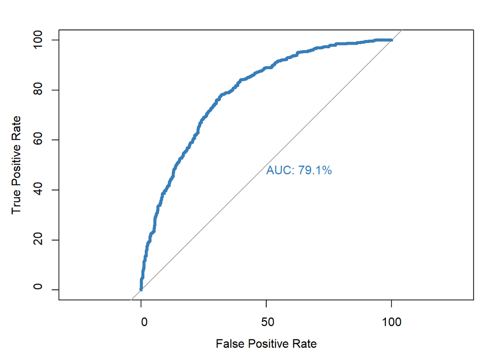

```r
# ROC Curve plot
output_roc <- roc(meteo_train$pluie.demain, meteo_train$mylogit_train_final_prob, plot=TRUE, legacy.axes=TRUE, percent=TRUE, xlab="False Positive Rate", ylab="True Positive Rate", col="#377eb8", lwd=4, print.auc=TRUE)
```

```r
cutoff = seq(0, 1, by=.001)
result = matrix(NA, nrow = length(cutoff), ncol = 3)
for(i in 1:length(cutoff)){
  pred = (meteo_train$mylogit_train_final_prob  >= cutoff[i])
  result[i,1] = mean(pred == (meteo_train$pluie.demain == "TRUE")) # Good Prediction
  result[i,2] = mean(abs(pred - (meteo_train$pluie.demain == "TRUE"))) # MAE
  result[i,3] = sqrt(mean(pred - (meteo_train$pluie.demain == "TRUE")^2)) # RMSE
}
cutoff_opt = c(cutoff[which.max(result[,1])], cutoff[which.min(result[,2])], cutoff[which.min(result[,3])])
```

```
## [1] "Seuil optimal en fonction du critère retenue (Taux de bonnes prédictions, MAE et RMSE)"
```

```
## [1] 0.492 0.492 0.537
```

```
## [1] "Nous sélectionnons automatiquement le seuil optimal qui permet de maximiser le taux de bonnes prévisions."
```

## Prévisions sur les données hors échantillon

Nous utilisons le modèle estimé dans mylogit_train_final, provenant du meilleur modèle B, pour faire nos prévisions sur la base de test. **A chaque exécution du code, le modèle optimal sera différent en raison de l’utilisation de l’algorithme génétique. C’est donc un choix délibéré de ne pas imposer ici une équation de modèle unique. En effet, les différences en terme de capacité prédictive observées sur l’échantillon d’apprentissage sont très proches d’une exécution (d’un modèle) à un autre.**

```r
# Forecast by using the test dataset
meteo_test = read.csv("meteo.test.csv")
#dput(names(meteo_test))
# Vérifier que j'ai bien renommé toutes les variables
names(meteo_test) <- c("X", "Year", "Month", "Day", "Hour", "Minute", "Temperature.Mean",
                        "RelHumidity.Mean", "Pressure.Mean",
                        "TotalPrecipitation.Sum", "Snowfall.Sum",
                        "TotalCloudCover.Mean", "HighCloudCover.Mean",
                        "MediumCloudCover.Mean", "LowCloudCover.Mean",
                        "SunshineDuration.Sum", "ShortwaveRadiation.Sum",
                        "WindSpeed.Mean.10m", "WindDirection.Mean.10m",
                        "WindSpeed.Mean.80m", "WindDirection.Mean.80m",
                        "WindSpeed.Mean.900hPa", "WindDirection.Mean.900hPa",
                        "WindGust.Mean", "Temperature.Max",
                        "Temperature.Min", "RelHumidity.Max",
                        "RelHumidity.Min", "Pressure.Max",
                        "Pressure.Min", "TotalCloudCover.Max",
                        "TotalCloudCover.Min", "HighCloudCover.Max",
                        "HighCloudCover.Min", "MediumCloudCover.Max",
                        "MediumCloudCover.Min", "LowCloudCover.Max",
                        "LowCloudCover.Min", "WindSpeed.Max.10m",
                        "WindSpeed.Min.10m", "WindSpeed.Max.80m",
                        "WindSpeed.Min.80m", "WindSpeed.Max.900hPa",
                        "WindSpeed.Min.900hPa", "WindGust.Max",
                        "WindGust.Min"
)

# There is no need to add or transform some covariates

# output in meteo_test
meteo_test$mylogit_test_final_prob = predict(mylogit_train_final, meteo_test, type="response")
meteo_test$mylogit_test_final_pred = (meteo_test$mylogit_test_final_prob >= cutoff_opt[1])

# output in .csv
write.csv(meteo_test,"meteo_test_final.csv")
```

Le fichier .csv contenant les prévisions est disponible dans le dossier dont vous avez renseigné le chemin en début du document.

Fin.

[^1]: Un modèle automatique de sélection de modèle avec la fonction glmulti() pourrait être lancé sur toutes ces variables. Toutefois, le nombre élevé de variables rend infaisable cette méthode. Par ailleurs, il est indispensable d’étudier aux préalables nos variables explicatives et de les lier au phénomène climatique que l’on cherche à prédire.
[^2]: La fonction bestglm() pourrait également être utilisée mais elle semble moins adéquate si le modèle est non linéaire.
[^3]: Puisque l’algorithme génétique est employée, il se peut que parfois les variables `TotalPrecipitation.Sum` et/ou `TotalCloudCover.Mean` n’apparaissent pas dans un des trois meilleurs modèles issus des modèles A et B, on peut également retrouver les variables `HighCloudCover.Max` et`Snowfall.Sum` mais puisque `HighCloudCover.Max` est très corrélée à `MediumCloudCover.Max` nous décidons de ne pas la mettre dans la constructions des modèles C, `Snowfall.Sum` n’étant pas significativement différente de 0, nous l’excluons également.